# AZENTA ImmunoSeq Analysis Report

## 1. Project Summary

| Customer Name: | Bulent Arman Aksoy |
| --- | --- |
| Email: | baksoy@obsidiantx.com |
| Quote Number: | 30-881296027 |
| Species: | human |
| Number of Samples: | 3 |
| Configuration: | Illumina Miseq 2X300PE |

## 2. Description of Workflow

### 2.1 ImmunoSeq Library Preparation Workflow

The diversity of B and T lymphocyte receptors is the key to the adaptive immune system. To leverage high-throughput sequencing for the characterization of B cell immunoglobulin repertoires and T cell receptor repertoires, total RNA is extracted from the isolated B/T lymphocytes and then reverse transcribed to cDNA. The complete 5’ end of BCR/TCR genes containing the variable regions are amplified by oligonucleotide primers against constant BCR/TCR constant regions. The resulting fragments were subject to final library preparation and next-generation sequencing.

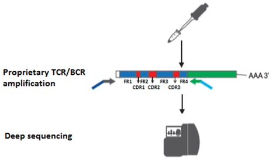

### 2.2 Bioinformatics Analysis Workflow

Raw sequencing data in fastq format were subject to quality filtering. Sequences that passed the quality filtering were mapped against IMGT database to find the best germline V(D)J gene matches. CDR sequences were then further characterized and analyzed.

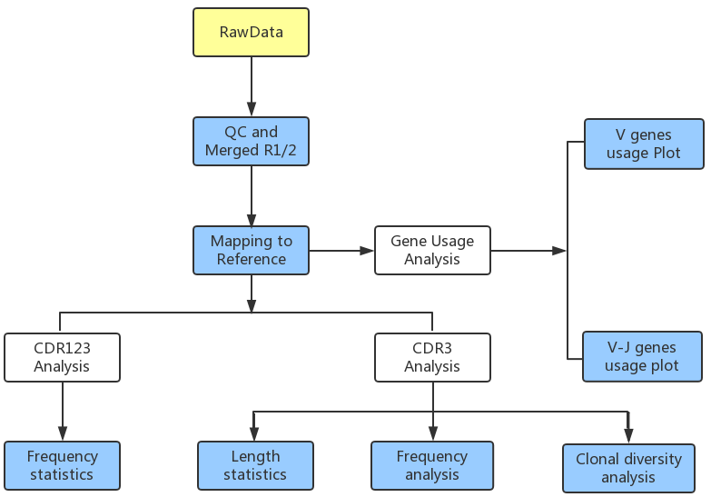

## 3. Analysis

### 3.1 Data Quality Control

For data from illumina platform, raw fastq files were first subject to quality assessment. Adapters and bases with poor quality scores (Q value lower than 20) were removed using Trimmomatic (v0.30) to generate clean data (trimmed data). Clean data were also subject to quality assessment. Statistics of data processing is summarized in below tables for raw reads and clean reads.

After quality control, reads were merged based on overlap between read1 and read2 to create a single contig for downstream analysis.

For data from Pacbio platform, CCS reads are always have high quality and are used for analysis without quality assessment step.

| Sample Name | Total Reads | Total Bases | Average Length | Q20% | Q30% | GC% | N% |
| --- | --- | --- | --- | --- | --- | --- | --- |
| IL15REP-RL1-2 | 3701662 | 1106482233 | 298.91 | 92.1 | 83.62 | 52.07 | 0 |
| IL15REP | 4642288 | 1384238122 | 298.18 | 92.68 | 84.45 | 52.02 | 0 |
| IL15REP-2 | 6729210 | 2014098075 | 299.31 | 93.25 | 85.67 | 48.03 | 0 |

| Sample Name | Total Reads | Total Bases | Average Length | Q20% | Q30% | GC% | N% |
| --- | --- | --- | --- | --- | --- | --- | --- |
| IL15REP-RL1-2 | 3520838 | 972231008 | 276.14 | 97.12 | 90.79 | 52.36 | 0 |
| IL15REP | 4436716 | 1231568263 | 277.59 | 97.18 | 90.96 | 52.32 | 0 |
| IL15REP-2 | 6440930 | 1807038269 | 280.56 | 97.4 | 91.66 | 47.91 | 0 |

### 3.2 Overall Sequencing Statistics

| Project ID | #Raw Reads | #Raw Bases | Q30% of Raw Data | #Clean Reads | #Clean Bases | Q30% of Clean Data | #Contigs | #Conitgs Bases |
| --- | --- | --- | --- | --- | --- | --- | --- | --- |
| 30-881296027 | 15073160 | 4504818430 | 84.79 | 14398484 | 4010837540 | 91.23 | 4339069 | 2289085833 |

### 3.3 Quality and Base Content Distribution

[interactive chart not shown]

### 3.4 Contig Length Distribution

For data from illumina sequencing platform, R1 and R2 reads are merged into contigs. For data from Pacbio sequencing platform, contigs is CCS reads which always have high quality. Below table dispalys the statistics and length distribution of these contigs.

| Sample Name | Total Contigs | Total Bases | Average Length | GC% | N% |
| --- | --- | --- | --- | --- | --- |
| IL15REP-RL1-2 | 1107085 | 580627228 | 524.46 | 52.28 | 0 |
| IL15REP | 1419258 | 749232885 | 527.9 | 52.25 | 0 |
| IL15REP-2 | 1812726 | 959225720 | 529.16 | 48.18 | 0 |

[interactive chart not shown]

### 3.5 Database Alignment Analysis

The assembled reads were blasted against IMGT reference database to identify the best match of germline V(D)J genes, and CDR1,CDR2,CDR3 variable region sequences. During the mapping and clusting, the clones’ abundance was calculated for each type of chain. For a detected CDR3 sequence, if CDR1 and CDR2 sequences were not detected from input assembled reads, ‘N’ and ‘X’ will be assigned according nucleotide sequence and amino acid sequence.

This table records all sequences for diferent regions.

| Sample Name | Chain type | CDR1 Nucleotide Sequence | CDR1 Amino acid Sequence | CDR2 Nucleotide Sequence | CDR2 Amino acid Sequence | CDR3 Nucleotide Sequence | CDR3 Amino acid Sequence | V Gene | D Gene | J Gene | Count | Frequency in Same CDR12 | Frequency in All |
| --- | --- | --- | --- | --- | --- | --- | --- | --- | --- | --- | --- | --- | --- |
| IL15REP-2 | TRA | ACATCTGGGTTCAACGGG | TSGFNG | AATGTTCTGGATGGTTTG | NVLDGL | TGTGCTGTGAGATCCTTACGGCGCTTT | CAVRSLRRF | TRAV1-2 |  | TRAJ43 | 50004 | 0.9771 | 0.3568 |
| IL15REP-2 | TRA | ACATCTGGGTTCAACGGG | TSGFNG | AATGTTCTGGATGGTTTG | NVLDGL | TGTGCTGTACCTCTGGATAGCAGCTATAAATTGATCTTC | CAVPLDSSYKLIF | TRAV1-2 |  | TRAJ12 | 1172 | 0.0229 | 0.0084 |
| IL15REP-2 | TRA | AACAGTGCTTCTCAGTCT | NSASQS | GTATACTCCAGTGGTAAT | VYSSGN | TGTGTGGTGACCTACACAGGCAAACTAATCTTT | CVVTYTGKLIF | TRAV12-1 |  | TRAJ37 | 37814 | 0.9469 | 0.2698 |
| IL15REP-2 | TRA | AACAGTGCTTCTCAGTCT | NSASQS | GTATACTCCAGTGGTAAT | VYSSGN | TGTGTGGTGAGGAAAACTGGGGCAAACAACCTCTTCTTT | CVVRKTGANNLFF | TRAV12-1 |  | TRAJ36 | 1363 | 0.0341 | 0.0097 |
| IL15REP-2 | TRA | AACAGTGCTTCTCAGTCT | NSASQS | GTATACTCCAGTGGTAAT | VYSSGN | TGTGTGGTGAGGTCCGCAGGATACAGCACCCTCACCTTT | CVVRSAGYSTLTF | TRAV12-1 |  | TRAJ11 | 398 | 0.01 | 0.0028 |
| IL15REP-2 | TRA | AACAGTGCTTCTCAGTCT | NSASQS | GTATACTCCAGTGGTAAT | VYSSGN | TGTGTGGTCTTGTCTAACGACTACAAGCTCAGCTTT | CVVLSNDYKLSF | TRAV12-1 |  | TRAJ20 | 360 | 0.009 | 0.0026 |
| IL15REP-2 | TRA | ACCAGTGATCCAAGTTATGGT | TSDPSYG | CAGGGGTCTTATGACCAGCAAAAT | QGSYDQQN | TGTGCAATGAGAGATGGGAACAACAGACTCGCTTTT | CAMRDGNNRLAF | TRAV14/DV4 |  | TRAJ7 | 16655 | 0.9743 | 0.1188 |
| IL15REP-2 | TRA | ACCAGTGATCCAAGTTATGGT | TSDPSYG | CAGGGGTCTTATGACCAGCAAAAT | QGSYDQQN | TGTGCAATGAGAGAGGGTGGCAATGACATGCGCTTT | CAMREGGNDMRF | TRAV14/DV4 |  | TRAJ43 | 439 | 0.0257 | 0.0031 |
| IL15REP-2 | TRA | AAGGCTTTATATTCT | KALYS | TTACTGAAGGGTGGAGAACAG | LLKGGEQ | TGTGGCACAGAGATACGGGCTGCAGGCAACAAGCTAACTTTT | CGTEIRAAGNKLTF | TRAV30 |  | TRAJ17 | 7686 | 1 | 0.0548 |
| IL15REP-2 | TRA | AACAGCGCCTCAGACTAC | NSASDY | ATTCGTTCAAATATGGACAAA | IRSNMDK | TGTGCAGAGAATACGGGAGGAGGAAACAAACTCACCTTT | CAENTGGGNKLTF | TRAV13-2 |  | TRAJ10 | 6741 | 0.9158 | 0.0481 |

[output cut: 82 more lines]

### 3.6 V(D)J Genes Usage Analysis

V(D)J recombination is a unique mechanism of genetic recombination that only occurs in developing lymphocytes during the early stages of T and B cell maturation. This mechanism results in many V(D)J combinations and thus the high diverse repertoire of the Immunoglobulins and T cell receptor combinations, respectively. By mapping to the IMGT database, the V(D)J diversity of each clone is shown below in below table.

#### 3.6.1 V gene usage

| Sample Name | Genes | Chain Type | Count | Frequency | Unique Count | Unique Frequency |
| --- | --- | --- | --- | --- | --- | --- |
| IL15REP-2 | TRAV1-2 | TRA | 51176 | 0.3651 | 6 | 0.125 |
| IL15REP-2 | TRAV12-1 | TRA | 39935 | 0.2849 | 5 | 0.1042 |
| IL15REP-2 | TRAV14/DV4 | TRA | 17094 | 0.122 | 2 | 0.0417 |
| IL15REP-2 | TRAV30 | TRA | 7686 | 0.0548 | 1 | 0.0208 |
| IL15REP-2 | TRAV13-2 | TRA | 7361 | 0.0525 | 3 | 0.0625 |
| IL15REP-2 | TRAV17 | TRA | 2771 | 0.0198 | 5 | 0.1042 |
| IL15REP-2 | TRAV13-1 | TRA | 2651 | 0.0189 | 5 | 0.1042 |
| IL15REP-2 | TRAV21 | TRA | 2457 | 0.0175 | 3 | 0.0625 |
| IL15REP-2 | TRAV24 | TRA | 1649 | 0.0118 | 2 | 0.0417 |
| IL15REP-2 | TRAV20 | TRA | 1593 | 0.0114 | 3 | 0.0625 |

[output cut: 40 more lines]

[interactive chart not shown]

#### 3.6.2 D gene usage

| Sample Name | Genes | Chain Type | Count | Frequency | Unique Count | Unique Frequency |
| --- | --- | --- | --- | --- | --- | --- |
| IL15REP-RL1-2 | TRBD2 | TRB | 557194 | 0.8505 | 21 | 0.4375 |
| IL15REP-RL1-2 | TRBD1 | TRB | 58443 | 0.0892 | 13 | 0.2708 |

#### 3.6.3 J gene usage

| Sample Name | Genes | Chain Type | Count | Frequency | Unique Count | Unique Frequency |
| --- | --- | --- | --- | --- | --- | --- |
| IL15REP-2 | TRAJ43 | TRA | 50682 | 0.3616 | 7 | 0.1458 |
| IL15REP-2 | TRAJ37 | TRA | 37814 | 0.2698 | 2 | 0.0417 |
| IL15REP-2 | TRAJ7 | TRA | 17380 | 0.124 | 2 | 0.0417 |
| IL15REP-2 | TRAJ17 | TRA | 7686 | 0.0548 | 1 | 0.0208 |
| IL15REP-2 | TRAJ10 | TRA | 7022 | 0.0501 | 2 | 0.0417 |
| IL15REP-2 | TRAJ36 | TRA | 3086 | 0.022 | 3 | 0.0625 |
| IL15REP-2 | TRAJ29 | TRA | 2487 | 0.0177 | 3 | 0.0625 |
| IL15REP-2 | TRAJ12 | TRA | 1815 | 0.013 | 3 | 0.0625 |
| IL15REP-2 | TRAJ24 | TRA | 1571 | 0.0112 | 3 | 0.0625 |
| IL15REP-2 | TRAJ22 | TRA | 1123 | 0.008 | 1 | 0.0208 |

[output cut: 40 more lines]

#### 3.6.4 V-J genes combining usage

[interactive chart not shown]

### 3.7 CDR3 Sequence Analysis

V(D)J recombination generates special CDR3 sequences which play very important role on contacting with antigen. Through alignment to database, CDR3 sequences are analyzed as below:

#### 3.7.1 CDR3 abundance analysis

| Sample Name | Clone ID | Clone Count | Clone Fraction | CDR3 Nucleotide Sequence | CDR3 Amino acid Sequence | V Gene | D Gene | J Gene | Chain Type |
| --- | --- | --- | --- | --- | --- | --- | --- | --- | --- |
| IL15REP-2 | 1 | 50004 | 0.3568 | TGTGCTGTGAGATCCTTACGGCGCTTT | CAVRSLRRF | TRAV1-2 |  | TRAJ43 | TRA |
| IL15REP-2 | 2 | 37814 | 0.2698 | TGTGTGGTGACCTACACAGGCAAACTAATCTTT | CVVTYTGKLIF | TRAV12-1 |  | TRAJ37 | TRA |
| IL15REP-2 | 3 | 16655 | 0.1188 | TGTGCAATGAGAGATGGGAACAACAGACTCGCTTTT | CAMRDGNNRLAF | TRAV14/DV4 |  | TRAJ7 | TRA |
| IL15REP-2 | 4 | 7686 | 0.0548 | TGTGGCACAGAGATACGGGCTGCAGGCAACAAGCTAACTTTT | CGTEIRAAGNKLTF | TRAV30 |  | TRAJ17 | TRA |
| IL15REP-2 | 5 | 6741 | 0.0481 | TGTGCAGAGAATACGGGAGGAGGAAACAAACTCACCTTT | CAENTGGGNKLTF | TRAV13-2 |  | TRAJ10 | TRA |
| IL15REP-2 | 6 | 1363 | 0.0097 | TGTGTGGTGAGGAAAACTGGGGCAAACAACCTCTTCTTT | CVVRKTGANNLFF | TRAV12-1 |  | TRAJ36 | TRA |
| IL15REP-2 | 7 | 1353 | 0.0097 | TGTGCTGTTGATCAAACTGGGGCAAACAACCTCTTCTTT | CAVDQTGANNLFF | TRAV22 |  | TRAJ36 | TRA |
| IL15REP-2 | 8 | 1172 | 0.0084 | TGTGCTGTACCTCTGGATAGCAGCTATAAATTGATCTTC | CAVPLDSSYKLIF | TRAV1-2 |  | TRAJ12 | TRA |
| IL15REP-2 | 9 | 1123 | 0.008 | TGTGCTGTGATCTCTGGTTCTGCAAGGCAACTGACCTTT | CAVISGSARQLTF | TRAV21 |  | TRAJ22 | TRA |
| IL15REP-2 | 10 | 1102 | 0.0079 | TGTGCCTTCCTCAATTCAGGAAACACACCTCTTGTCTTT | CAFLNSGNTPLVF | TRAV24 |  | TRAJ29 | TRA |

[output cut: 81 more lines]

#### 3.7.2 CDR3 length analysis

| Sample Name | CDR3 length | Count | Frequency | Unique Count | Unique Frequency | Chain Type |
| --- | --- | --- | --- | --- | --- | --- |
| IL15REP-2 | 9 | 50243 | 0.3585 | 6 | 0.125 | TRA |
| IL15REP-2 | 11 | 39226 | 0.2799 | 5 | 0.1042 | TRA |
| IL15REP-2 | 12 | 17454 | 0.1245 | 3 | 0.0625 | TRA |
| IL15REP-2 | 13 | 16658 | 0.1189 | 16 | 0.3333 | TRA |
| IL15REP-2 | 14 | 11061 | 0.0789 | 8 | 0.1667 | TRA |
| IL15REP-2 | 15 | 2867 | 0.0205 | 6 | 0.125 | TRA |
| IL15REP-2 | 16 | 1690 | 0.0121 | 3 | 0.0625 | TRA |
| IL15REP-2 | 10 | 955 | 0.0068 | 1 | 0.0208 | TRA |
| IL15REP | 9 | 13 | 0.3939 | 3 | 0.1667 | TRA |
| IL15REP | 13 | 8 | 0.2424 | 6 | 0.3333 | TRA |

[output cut: 13 more lines]

*‘Number of Unique’ represent the unique clone sequences are calculated without considering abundance informance.*

[interactive chart not shown]

### 3.8 CDR3 Sequence Clustering Analysis

To analyze CDR3 amino acid usage frequency, CDR3 sequences were clustered according to similarity (threshold: 0.8). The summary of top 20 clusters of each chain of each sample is shown below table. Weblogo software was used for visualizing CDR3 amino acid patterns of each cluster. Each logo consists of stacks of symbols and the size of letter represents its frequency from unique and abundance levels. All tables and weblogo pictures can be accessed in supplement folder.

| Sample | Chain | ClusterID | Total_Count | PCT_Total_Count | Unique_Count | PCT_Total_Count | Richest_CDR3_Seq | Richest_CDR3_Length |
| --- | --- | --- | --- | --- | --- | --- | --- | --- |
| IL15REP-2 | TRA | Cluster37 | 50004 | 35.68 | 1 | 2.33 | CAVRSLRRF | 9 |
| IL15REP-2 | TRA | Cluster33 | 37814 | 26.98 | 1 | 2.33 | CVVTYTGKLIF | 11 |
| IL15REP-2 | TRA | Cluster30 | 16655 | 11.88 | 1 | 2.33 | CAMRDGNNRLAF | 12 |
| IL15REP-2 | TRA | Cluster9 | 7686 | 5.48 | 1 | 2.33 | CGTEIRAAGNKLTF | 14 |
| IL15REP-2 | TRA | Cluster17 | 7022 | 5.01 | 2 | 4.65 | CAENTGGGNKLTF | 13 |
| IL15REP-2 | TRA | Cluster2 | 1723 | 1.23 | 2 | 4.65 | CAVDQTGANNLFF | 13 |
| IL15REP-2 | TRA | Cluster6 | 1605 | 1.15 | 2 | 4.65 | CAVPLDSSYKLIF | 13 |
| IL15REP-2 | TRA | Cluster18 | 1363 | 0.97 | 1 | 2.33 | CVVRKTGANNLFF | 13 |
| IL15REP-2 | TRA | Cluster19 | 1123 | 0.8 | 1 | 2.33 | CAVISGSARQLTF | 13 |
| IL15REP-2 | TRA | Cluster20 | 1102 | 0.79 | 1 | 2.33 | CAFLNSGNTPLVF | 13 |

[output cut: 43 more lines]

[interactive chart not shown]

### 3.9 Correlation of CDR3 Abundance

Bsed on the samples’ CDR3 abundance, heatmap plot can show the similarity between different samples. Here, PEARSON index was used to represent similarity of samples and chain type was also treated separately.

[interactive chart not shown]

### 3.10 Clonal Diversity Analysis

The clonal abundance distribution was calculated with confidence intervals derived via bootstrapping method. Bootstrapping method uses random sampling and replacement to assign measures of accuracy and confidance. The clonal diversity of the repertoire was accessed using diversity index.

Diversity index is proposed by Hill(Hill, 1973), quantifies diversity as a smooth function (D) of a single parameter q. Special cases of the generalized diversity index correspond to the most popular diversity measures in ecology: species richness (q = 0), the exponential of the Shannon-Weiner index (q approaches 1), the inverse of the Simpson index (q = 2), and the reciprocal abundance of the largest clone (q approaches +infinity). At q = 0 different clones weight equally, regardless of their size. As the parameter q increase from 0 to +infinity the diversity index (D) depends less on rare clones and more on common (abundant) ones, thus encompassing a range of definitions that can be visualized as a single curve.

[interactive chart not shown]